# Descriptive Analysis

Nilabja Ray

8 May 2018

### Variable Summaries

```r
dat = readRDS('data/final_data_jan_17.RDS')
```

#### 1. Location

It is a factor with 53 levels. The interaction with target variable is as shown below:

```r
dat[,.(acc_count = .N,target_positive = sum(target),perc=sum(target)*100/.N),Location][order(-acc_count,-perc)]
```

| Location | acc_count | target_positive | perc |
| --- | --- | --- | --- |
| Delhi | 1495 | 115 | 7.6923077 |
| Mumbai | 696 | 40 | 5.7471264 |
| Jaipur | 495 | 9 | 1.8181818 |
| Pune | 489 | 38 | 7.7709611 |
| Chennai | 300 | 6 | 2.0000000 |
| Noida | 267 | 7 | 2.6217228 |
| Bargarh | 247 | 11 | 4.4534413 |
| BHUBANESWAR | 235 | 9 | 3.8297872 |
| Jodhpur | 234 | 12 | 5.1282051 |
| Bangalore | 224 | 27 | 12.0535714 |

[output cut: 43 more lines]

The Number of levels is too high to have clear idea about impact of location on target.

#### 2. State

Factor with 16 levels.

```r
dat[,.(acc_count = .N,target_positive = sum(target),perc=sum(target)*100/.N),state][order(-acc_count,-perc)]
```

| state | acc_count | target_positive | perc |
| --- | --- | --- | --- |
| Delhi - NCR | 1762 | 122 | 6.923950 |
| Maharashtra | 1300 | 80 | 6.153846 |
| Rajasthan | 826 | 30 | 3.631961 |
| Orissa | 581 | 28 | 4.819277 |
| Tamilnadu | 388 | 7 | 1.804124 |
| Gujarat | 228 | 4 | 1.754386 |
| Karnataka | 224 | 27 | 12.053571 |
| Madhya Pradesh | 204 | 5 | 2.450980 |
| Telangana | 124 | 2 | 1.612903 |
| CHATTISHGAR | 113 | 7 | 6.194690 |

[output cut: 6 more lines]

The rate of delinquincy is higher for Delhi, Maharashtra and Karnataka. Punjab also is high, but sample size is too small.

**Only state will be used in the model - location will not be used.**

#### 3. Product

Factor with 3 different levels

```r
dat[,.(acc_count = .N,target_positive = sum(target),perc=sum(target)*100/.N),Product][order(-acc_count,-perc)]
```

| Product | acc_count | target_positive | perc |
| --- | --- | --- | --- |
| COMMERCIAL VEHICLE | 4582 | 256 | 5.587080 |
| COMMERCIAL VEHICLE - AIB | 979 | 47 | 4.800817 |
| COMMERCIAL VEHICLE - Trailer Funding | 381 | 18 | 4.724409 |

We used this variable to create the flag `isAgri`.

```r
dat[,.(acc_count = .N,target_positive = sum(target),perc=sum(target)*100/.N),isAgri][order(-acc_count,-perc)]
```

| isAgri | acc_count | target_positive | perc |
| --- | --- | --- | --- |
| FALSE | 4963 | 274 | 5.520854 |
| TRUE | 979 | 47 | 4.800817 |

i.e. Non-agri products have higher default rate than agri products.

#### 4. Loan_purpose

Factor with 9 levels.

```r
dat[,.(acc_count = .N,target_positive = sum(target),perc=sum(target)*100/.N),Loan_purpose][order(-acc_count,-perc)]
```

| Loan_purpose | acc_count | target_positive | perc |
| --- | --- | --- | --- |
| New Vehicle Purchase | 2150 | 125 | 5.813953 |
|  | 1351 | 64 | 4.737232 |
| NEW_CHASIS | 1002 | 60 | 5.988024 |
| Used Vehicle Purchase | 376 | 13 | 3.457447 |
| NEW_BODY | 336 | 22 | 6.547619 |
| Refinance Existing Vehicle | 252 | 14 | 5.555556 |
| NEW_FULLY_BUILT_VEHICLE | 194 | 7 | 3.608247 |
| USED_VEHICLE | 182 | 9 | 4.945055 |
| REFINANCE_VEHICLE | 99 | 7 | 7.070707 |

#### 5. PROMOTIONDESC

Factor with 24 levels.

```r
dat[,.(acc_count = .N,target_positive = sum(target),perc=sum(target)*100/.N),PROMOTIONDESC][order(-acc_count,-perc)]
```

| PROMOTIONDESC | acc_count | target_positive | perc |
| --- | --- | --- | --- |
| TRANSPORTER C CATEGORY | 1165 | 37 | 3.175966 |
| TRANSPORTER D CATEGORY | 1058 | 42 | 3.969754 |
| FIRST TIME BUYER | 750 | 43 | 5.733333 |
| TRANSPORTER B CATEGORY | 606 | 23 | 3.795380 |
| Small Commercial Vehicles 2 | 477 | 26 | 5.450734 |
| FIRST TIME USER | 461 | 25 | 5.422993 |
| TRANSPORTER A CATEGORY | 324 | 83 | 25.617284 |
| Bus Operator - Retail Small Operators | 222 | 11 | 4.954955 |
| CAPTIVE D CATEGORY | 164 | 5 | 3.048780 |
| Small Commercial Vehicles -Retail | 141 | 5 | 3.546099 |

[output cut: 14 more lines]

TRANSPORTER A CATEGORY has exceptionally high default potential.

#### 6. CONSTITUTION

```r
dat[,.(acc_count = .N,target_positive = sum(target), perc=sum(target)*100/.N),
    CONSTITUTION][order(-acc_count,-perc)]
```

| CONSTITUTION | acc_count | target_positive | perc |
| --- | --- | --- | --- |
| Individual | 5131 | 225 | 4.385110 |
| Private Limited Co | 323 | 81 | 25.077399 |
| Proprietor | 238 | 6 | 2.521008 |
| Partnership Firm | 199 | 7 | 3.517588 |
| Trust | 32 | 1 | 3.125000 |
| Society | 10 | 0 | 0.000000 |
| Others | 7 | 0 | 0.000000 |
| Public Limited Co | 1 | 1 | 100.000000 |
| Limited Liability Partnership | 1 | 0 | 0.000000 |

#### 7. DISBDT

```r
dat[,.(acc_count = .N,target_positive=sum(target),perc=sum(target)*100/.N),by=.(Month=as.yearqtr(DISBDT))][order(Month)]
```

| Month | acc_count | target_positive | perc |
| --- | --- | --- | --- |
| 2012 Q4 | 5 | 0 | 0.000000 |
| 2013 Q1 | 31 | 4 | 12.903226 |
| 2013 Q2 | 46 | 0 | 0.000000 |
| 2013 Q3 | 81 | 5 | 6.172840 |
| 2013 Q4 | 102 | 5 | 4.901961 |
| 2014 Q1 | 216 | 16 | 7.407407 |
| 2014 Q2 | 286 | 38 | 13.286713 |
| 2014 Q3 | 301 | 13 | 4.318937 |
| 2014 Q4 | 371 | 11 | 2.964960 |
| 2015 Q1 | 431 | 15 | 3.480278 |

[output cut: 6 more lines]

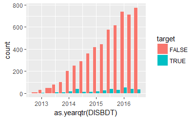

```r
ggplot(dat,aes(x=as.yearqtr(DISBDT)))+geom_bar(aes(fill=target),position = position_dodge())
```

#### 8. DISB_AMT

Continuous variable. Can be binned to convert to categorical. **Summary**

```r
summary(dat$DISB_AMT)
```

```
   Min. 1st Qu.  Median    Mean 3rd Qu.    Max.
  62489  400000 1055816 1127509 1809926 3192000
```

In order to check the impact of DISB_AMT on our target varibale, we conduct a non-parametric comparison of the variable for target=0 and target=1.

```r
wilcox.test(DISB_AMT~target,data=dat)
```

```
    Wilcoxon rank sum test with continuity correction

data:  DISB_AMT by target
W = 804490, p-value = 0.001084
alternative hypothesis: true location shift is not equal to 0
```

Since the P-value is small enough, we conclude that the DISB_AMT has some impact on the target. For better visualisation, a violin plot is created.

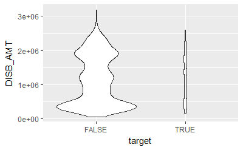

```r
ggplot(dat,aes(target,DISB_AMT))+geom_violin(scale = "count")
```

#### 9. roi

Numeric variable

```r
summary(dat$roi)
```

```
   Min. 1st Qu.  Median    Mean 3rd Qu.    Max.
  10.76   11.94   12.60   13.19   14.35   19.19
```

** Mann-Whitney U Test **

```r
wilcox.test(roi~target,data=dat)
```

```
    Wilcoxon rank sum test with continuity correction

data:  roi by target
W = 873980, p-value = 0.3456
alternative hypothesis: true location shift is not equal to 0
```

Since there is no significant difference in the roi for target 0 and target 1, it will not be included in the model.

#### 10. MANUFACTURERDESC

Factor - has 15 levels.

```r
dat[,.(acc_count = .N,target_positive=sum(target),perc=sum(target)*100/.N),
    MANUFACTURERDESC][order(-perc)]
```

| MANUFACTURERDESC | acc_count | target_positive | perc |
| --- | --- | --- | --- |
| PRIVATE BODY BUILDER | 334 | 29 | 8.682635 |
| ASHOK LEYLAND LTD | 1286 | 72 | 5.598756 |
| TATA MOTORS LTD | 3631 | 203 | 5.590746 |
| SWARAJ MAZDA | 56 | 3 | 5.357143 |
| BHARAT BENZ | 21 | 1 | 4.761905 |
| MAHINDRA AND MAHINDRA | 203 | 9 | 4.433498 |
| FORCE MOTORS | 68 | 1 | 1.470588 |
| VE COMMERCIAL VEHICLES LTD | 322 | 3 | 0.931677 |
| ASIA MOTOR WORKS LTD | 2 | 0 | 0.000000 |
| JAY BAJRANG MOTOR BODY REPAIRS | 1 | 0 | 0.000000 |

[output cut: 5 more lines]

It is found that the default rate is higher for Private Body Builders.

#### 11. CATGDESC

Factor with 10 levels.

```r
dat[,.(acc_count = .N,target_positive=sum(target),perc=sum(target)*100/.N),
    CATGDESC][order(-perc)]
```

| CATGDESC | acc_count | target_positive | perc |
| --- | --- | --- | --- |
| BODY | 61 | 9 | 14.754098 |
| M&HCV | 1021 | 63 | 6.170421 |
| HCV | 2916 | 163 | 5.589849 |
| MCV | 96 | 5 | 5.208333 |
| SCV | 1040 | 52 | 5.000000 |
| BUS | 297 | 11 | 3.703704 |
| LCV | 466 | 17 | 3.648069 |
| TT | 40 | 1 | 2.500000 |
| TIPPERS | 4 | 0 | 0.000000 |
| MUV | 1 | 0 | 0.000000 |

** Joint Distribution of CATGDESC and MANUFACTURERDESC

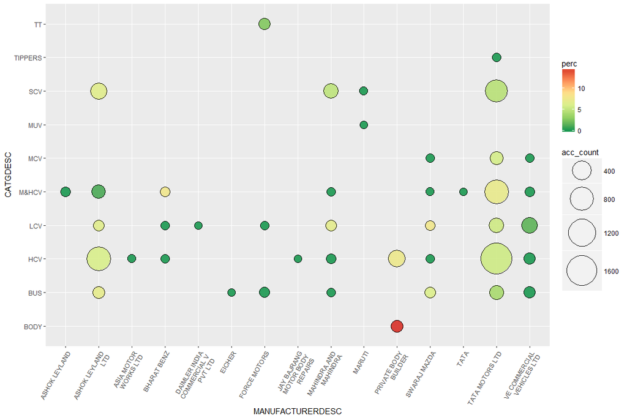

```r
tempdat= dat[,.(acc_count =.N, target_positive=sum(target), perc=sum(target)*100/.N),
             by=.(MANUFACTURERDESC,CATGDESC)]
a = ggplot(data=tempdat,aes(x=MANUFACTURERDESC,y=CATGDESC))+
  geom_point(aes(size=acc_count,fill=perc),shape=21,alpha=.9)+
  scale_size(range = c(5, 20)) +
  theme(axis.text.x = element_text(angle=60,hjust=1))+
  scale_x_discrete(labels=function(x) str_wrap(x,15))
a+scale_fill_distiller(palette = "RdYlGn")
```

#### 12. ASSETCOST

Continuous variable

```r
summary(dat[,ASSETCOST])
```

```
   Min. 1st Qu.  Median    Mean 3rd Qu.    Max.
 150000  747000 1378500 1371524 1950000 3900000
```

**Loan to Asset Cost Ratio**

Created the new column - continuous

```r
dat[,LAR:=DISB_AMT/ASSETCOST]
summary(dat[,LAR])
```

```
   Min. 1st Qu.  Median    Mean 3rd Qu.    Max.
0.03532 0.76018 0.89640 0.81228 0.99996 5.46154
```

```r
dat[,mean(LAR),target]
```

| target | V1 |
| --- | --- |
| FALSE | 0.8097554 |
| TRUE | 0.8564969 |

```r
wilcox.test(LAR~target,data=dat)
```

```
    Wilcoxon rank sum test with continuity correction

data:  LAR by target
W = 804350, p-value = 0.0009937
alternative hypothesis: true location shift is not equal to 0
```

```r
wilcox.test(DISB_AMT~target,data=dat)
```

```
    Wilcoxon rank sum test with continuity correction

data:  DISB_AMT by target
W = 804490, p-value = 0.001084
alternative hypothesis: true location shift is not equal to 0
```

```r
wilcox.test(ASSETCOST~target,data=dat)
```

```
    Wilcoxon rank sum test with continuity correction

data:  ASSETCOST by target
W = 857390, p-value = 0.1341
alternative hypothesis: true location shift is not equal to 0
```

LAR has significant impact on target.

#### 13. assetlevel

```r
dat[,.(acc_count = .N,target_positive=sum(target),perc=sum(target)*100/.N),
    asset_level][order(-perc)]
```

| asset_level | acc_count | target_positive | perc |
| --- | --- | --- | --- |
| Level 1 | 5714 | 315 | 5.512776 |
| Level 2 | 149 | 5 | 3.355705 |
| Level 3 | 58 | 1 | 1.724138 |
|  | 21 | 0 | 0.000000 |

#### 14. POS

```r
summary(dat[target==TRUE,POS])
```

```
   Min. 1st Qu.  Median    Mean 3rd Qu.    Max.
  31506  321171  636243  828487 1214589 2414538
```

```r
summary(dat[target==FALSE,POS])
```

```
   Min. 1st Qu.  Median    Mean 3rd Qu.    Max.
   3064  225045  528288  739804 1184185 2645493
```

```r
wilcox.test(POS~target,data=dat)
```

```
    Wilcoxon rank sum test with continuity correction

data:  POS by target
W = 801570, p-value = 0.0007647
alternative hypothesis: true location shift is not equal to 0
```

#### 15. DPD_Day

```r
summary(dat[,DPD_Days])
```

```
   Min. 1st Qu.  Median    Mean 3rd Qu.    Max.
  0.000   0.000   0.000   2.038   0.000  30.000
```

```r
summary(dat[target==TRUE,DPD_Days])
```

```
   Min. 1st Qu.  Median    Mean 3rd Qu.    Max.
   0.00    0.00    7.00   11.02   27.00   30.00
```

```r
summary(dat[target==FALSE,DPD_Days])
```

```
   Min. 1st Qu.  Median    Mean 3rd Qu.    Max.
  0.000   0.000   0.000   1.525   0.000  30.000
```

```r
dat[,.N,DPD_Days]
```

| DPD_Days | N |
| --- | --- |
| 30 | 63 |
| 0 | 5303 |
| 17 | 143 |
| 7 | 195 |
| 27 | 238 |

#### 16. Bounces

```r
addmargins(prop.table(xtabs(N~Bounces+target,data=dat[,.N,.(target,Bounces)]),margin = 1),2)
```

```
       target
Bounces      FALSE       TRUE        Sum
  FALSE 0.97138315 0.02861685 1.00000000
  TRUE  0.80549451 0.19450549 1.00000000
```

#### 17. ever_60, ever_30, ever_x

```r
temp_tot = dat[,.(.N,target_positive=sum(target))]
temp_x = dat[ever_x==TRUE,.(.N,target_positive=sum(target))]
temp_30 = dat[ever_30==TRUE,.(.N,target_positive=sum(target))]
temp_60 = dat[ever_60==TRUE,.(.N,target_positive=sum(target))]
temp=rbind(temp_tot,temp_x,temp_30,temp_60)
temp[,perc:=100*target_positive/N]
rm(temp_30,temp_60,temp_tot,temp_x)
cbind(filter=c('None','ever_x','ever_30','ever_60'),temp)
```

| filter | N | target_positive | perc |
| --- | --- | --- | --- |
| None | 5942 | 321 | 5.402221 |
| ever_x | 1288 | 228 | 17.701863 |
| ever_30 | 253 | 62 | 24.505929 |
| ever_60 | 82 | 21 | 25.609756 |

#### 18. total_bounces

```r
summary(dat[,total_bounces])
```

```
   Min. 1st Qu.  Median    Mean 3rd Qu.    Max.
  0.000   0.000   0.000   2.013   2.000  38.000
```

```r
temp=dat[,.(.N,target_positive=sum(target)),cut(total_bounces,breaks = c(0,1,10,20,30,100),right = FALSE)]
temp[,perc:=target_positive*100/N][order(-perc)]
```

| cut | N | target_positive | perc |
| --- | --- | --- | --- |
| [20,30) | 45 | 12 | 26.666667 |
| [10,20) | 255 | 49 | 19.215686 |
| [30,100) | 22 | 4 | 18.181818 |
| [1,10) | 2386 | 196 | 8.214585 |
| [0,1) | 3234 | 60 | 1.855288 |

#### 19. Presentation

```r
addmargins(prop.table(xtabs(~Presentations+target,data=dat),1),2)
```

```
             target
Presentations      FALSE       TRUE        Sum
        FALSE 0.95368171 0.04631829 1.00000000
        TRUE  0.94470588 0.05529412 1.00000000
```

#### 20. category

```r
dat[,.(acc_count = .N,target_positive=sum(target),perc=sum(target)*100/.N),
    category][order(-perc)]
```

| category | acc_count | target_positive | perc |
| --- | --- | --- | --- |
| Transporter | 3246 | 189 | 5.822551 |
| FTB | 769 | 43 | 5.591678 |
| FTU | 461 | 25 | 5.422993 |
| Farmers | 79 | 4 | 5.063291 |
| SCV | 639 | 32 | 5.007825 |
| Bus | 418 | 18 | 4.306220 |
| LCV | 56 | 2 | 3.571429 |
| Captive | 209 | 7 | 3.349282 |
| School | 65 | 1 | 1.538462 |

#### 21. cash_payment

```r
dat[,.(acc_count = .N,target_positive=sum(target),perc=sum(target)*100/.N),
    cash_payment][order(-perc)]
```

| cash_payment | acc_count | target_positive | perc |
| --- | --- | --- | --- |
| FALSE | 5100 | 282 | 5.529412 |
| TRUE | 842 | 39 | 4.631829 |

22. br_6m,br_3m

```r
summary(dat[cash_payment==FALSE,br_6m])
```

```
   Min. 1st Qu.  Median    Mean 3rd Qu.    Max.
  0.000   0.000   0.000   0.176   0.200   1.000
```

```r
summary(dat[cash_payment==FALSE,br_3m])
```

```
   Min. 1st Qu.  Median    Mean 3rd Qu.    Max.
 0.0000  0.0000  0.0000  0.1774  0.3333  1.0000
```

```r
sum(is.na(dat[cash_payment==FALSE,br_6m]))
```

```
[1] 0
```

```r
sum(is.na(dat[cash_payment==FALSE,br_3m]))
```

```
[1] 0
```

23. MOB

```r
summary(dat$MOB)
```

```
   Min. 1st Qu.  Median    Mean 3rd Qu.    Max.
   4.00    9.00   15.00   17.36   24.00   51.00
```

```r
summary(dat[target==TRUE,MOB])
```

```
   Min. 1st Qu.  Median    Mean 3rd Qu.    Max.
   4.00   10.00   17.00   18.54   28.00   47.00
```

```r
summary(dat[target==FALSE,MOB])
```

```
   Min. 1st Qu.  Median    Mean 3rd Qu.    Max.
    4.0     9.0    15.0    17.3    24.0    51.0
```

### Independence of Presentation and cash_payment

```r
xtabs(~Presentations+cash_payment,data=dat)
```

```
             cash_payment
Presentations FALSE TRUE
        FALSE     0  842
        TRUE   5100    0
```